# Academic Innovation

BA200 Fall 2019

Amy Lu, mingchlu@umich.edu

March 12, 2020

## Objective

**Are there any significant differences in how students in different sections or with different demographics responded to BOT and EOT surveys?**

There are total of 616 students and 16 sections. The locations include Central, A2, North, Hill, and Far.

Variables interested:

1. `Eval_Use`:  
   How interested would you be in using Tandem again? Scale from 1 to 5 (not at all interested to very interested).
2. `Eval_Useful`:  
   How useful do you think Tandem was to you this term? Scale from 1 to 5 (not at all useful to very useful).
3. `BT/ET_Orientation`:  
   If I could only get one outcome from BA200, it would be most important for me to:
   - [Grade] Earn a good grade
   - [Performance] Be among the top performing teams in $Course
   - [Learn] Understand the subject well
   - [Practice] Get practice with the relevant skills
   - [Groupwork] Improve my ability to work with a group
   - [None] None of the above
4. `GroupPreference/ET_GroupPreference`:  
   If given an option, I’d prefer to:
   - [Alone] Work alone
   - [Partner] Work with one partner
   - [Group] Work in a group

## Orientation

### Descriptive Statistics

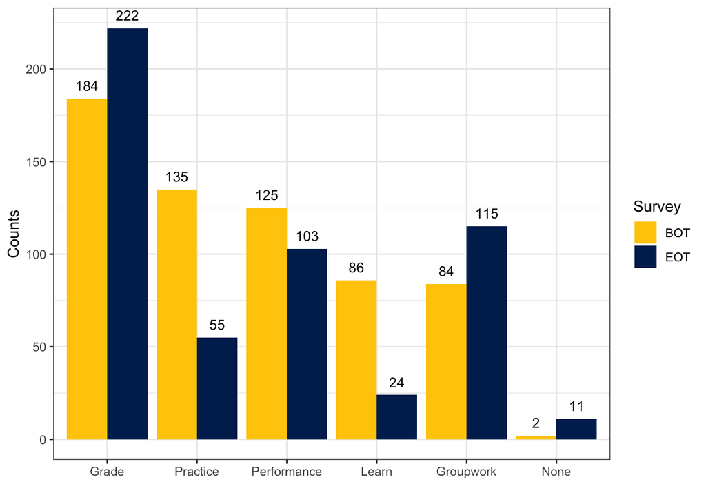

**Figure 1.** *Number of students for each outcome.* Grade remains the highest frequency while the frequency of Practice decreases and the frequency of Groupwork increases as the course moved toward the end of the term. The total counts are 616 students for BOT and 530 students for EOT.

```r
BT_O = data.frame(table(BOT$sections, BOT$BT_Orientation))
colnames(BT_O) = c("sections", "Orientation", "BOT")
BT_O = BT_O %>% group_by(Orientation) %>% summarise(BOT = sum(BOT))

ET_O = data.frame(table(EOT$sections, EOT$ET_Orientation))
colnames(ET_O) = c("sections", "Orientation", "EOT")
ET_O = ET_O %>% group_by(Orientation) %>% summarise(EOT = sum(EOT))

df_O = left_join(BT_O, ET_O, by = c("Orientation"))

cap = paste0("**Figure 1.** *Number of students for each outcome.* Grade ",
            "remains the highest frequency while the frequency of Practice ",
            "decreases and the frequency of Groupwork increases as the ",
            "course moved toward the end of the term. The total counts are 616",
            " students for BOT and 530 students for EOT.")

pivot_longer(df_O, 2:3) %>%
  group_by(name) %>% arrange(-value) %>%
  mutate(Orientation =
           factor(Orientation,
                  levels = c("Grade", "Practice", "Performance",
                             "Learn", "Groupwork", "None"))) %>%
  ggplot(aes(x = Orientation, y = value, fill = name)) +
  geom_bar(position="dodge", stat="identity") +
  geom_text(aes(label=value), vjust=-.8, color="black",
            position = position_dodge(0.9), size=3.5) +
  ylab("Counts") + labs(fill = "Survey") + xlab("") +
  scale_fill_manual(values = c("#FFcb05", "#00285E")) +
  theme_bw()
```

```r
t = as.table(cbind(as.numeric(df_O$BOT), as.numeric(df_O$EOT)))
dimnames(t) = list(Orientation = c("Grade", "Performance", "Learn",
                                   "Practice", "Groupwork", "None"),
                   Term = c("BOT", "EOT"))
chisq = chisq.test(t, correct=FALSE)
```

*The Pearson’s Chi-squared test shows that the `Orientation` for BOT and EOT are different at level $\alpha$ = .05 ($p$-value < 0.00).*

### Interaction between options

```r
df = EOT %>% left_join(BOT, by = "user_id") %>%
  select(user_id, BT_Orientation, ET_Orientation) %>% drop_na()
df$BT_Orientation = factor(df$BT_Orientation,
                           levels = c("Grade", "Practice", "Performance",
                                      "Learn", "Groupwork", "None"))
df$ET_Orientation = factor(df$ET_Orientation,
                           levels = c("Grade", "Practice", "Performance",
                                      "Learn", "Groupwork", "None"))

tbl = table(BOT = df$BT_Orientation, EOT = df$ET_Orientation)
tbl = prop.table(tbl, 1)

df_tbl =
  as.data.frame(table(BOT = df$BT_Orientation, EOT = df$ET_Orientation)) %>%
  left_join(as.data.frame(tbl), by = c("BOT", "EOT")) %>%
  mutate(Freq = sprintf("%.0f (%.0f%%)", Freq.x, Freq.y*100)) %>%
  select(BOT, EOT, Freq) %>%
  rename(`Frequency (Percentage)` = Freq) %>%
  arrange(BOT)

wide = pivot_wider(df_tbl, names_from = EOT, values_from = `Frequency (Percentage)`)
names(wide)[1] = ""

knitr::kable(wide)
```

|  | Grade | Practice | Performance | Learn | Groupwork | None |
| --- | --- | --- | --- | --- | --- | --- |
| Grade | 108 (71%) | 3 (2%) | 22 (14%) | 4 (3%) | 12 (8%) | 4 (3%) |
| Practice | 34 (30%) | 24 (21%) | 16 (14%) | 6 (5%) | 32 (28%) | 3 (3%) |
| Performance | 30 (28%) | 5 (5%) | 42 (39%) | 4 (4%) | 24 (22%) | 2 (2%) |
| Learn | 20 (28%) | 13 (18%) | 14 (19%) | 8 (11%) | 16 (22%) | 1 (1%) |
| Groupwork | 28 (36%) | 9 (12%) | 8 (10%) | 2 (3%) | 30 (38%) | 1 (1%) |
| None | 1 (50%) | 0 (0%) | 0 (0%) | 0 (0%) | 1 (50%) | 0 (0%) |

### Interaction between options by section

```r
df_sec = EOT %>% left_join(BOT, by = c("user_id", "sections")) %>%
  transmute(user_id, BT_Orientation, ET_Orientation,
            sections = str_remove(sections, "Section 0"))
df_sec$BT_Orientation = factor(df_sec$BT_Orientation,
                           levels = c("Grade", "Practice", "Performance",
                                      "Learn", "Groupwork", "None"))
df_sec$ET_Orientation = factor(df_sec$ET_Orientation,
                           levels = c("Grade", "Practice", "Performance",
                                      "Learn", "Groupwork", "None"))

tbl_sec = table(BOT = df_sec$BT_Orientation, EOT = df_sec$ET_Orientation,
                Section = df_sec$sections)
tbl_sec = prop.table(tbl_sec, c(3,1))

df_tbl_sec = as.data.frame(prop.table(tbl_sec, c(3,1))) %>%
  transmute(Section, BOT, EOT, Freq = sprintf("%2.0f%%", Freq*100)) %>%
  arrange(BOT)

wide = pivot_wider(df_tbl_sec, names_from = EOT, values_from = Freq)
names(wide)[2] = "BOT \\ EOT"

options(DT.options = list(pageLength = 16))
datatable(wide, rownames = F, options = list(
  columnDefs = list(list(className = 'dt-center', targets = "_all"))))
```

| Section | BOT \ EOT | Grade | Practice | Performance | Learn | Groupwork | None |
| --- | --- | --- | --- | --- | --- | --- | --- |
| 01 | Grade | 75% | 8% | 8% | 8% | 0% | 0% |
| 02 | Grade | 90% | 0% | 10% | 0% | 0% | 0% |
| 03 | Grade | 75% | 0% | 0% | 12% | 12% | 0% |
| 04 | Grade | 75% | 0% | 0% | 12% | 12% | 0% |
| 05 | Grade | 78% | 0% | 11% | 0% | 11% | 0% |
| 06 | Grade | 73% | 0% | 18% | 0% | 9% | 0% |
| 07 | Grade | 44% | 11% | 33% | 0% | 11% | 0% |
| 08 | Grade | 86% | 0% | 14% | 0% | 0% | 0% |
| 09 | Grade | 78% | 0% | 22% | 0% | 0% | 0% |
| 10 | Grade | 67% | 0% | 11% | 0% | 22% | 0% |

[output cut: 86 more lines]

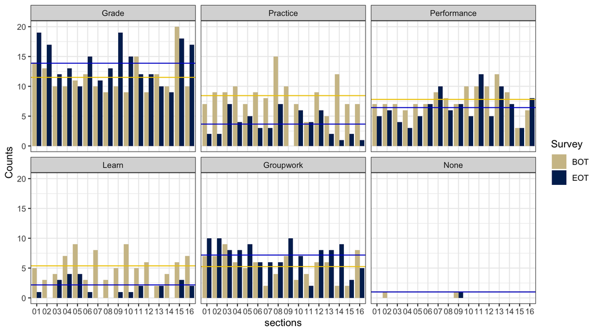

**Figure 2.** *Number of students for each outcome of Orientation for 16 sections.* The yellow and blue lines represent the average counts for BOT and EOT respectively.

```r
BT_Os = BOT %>% group_by(sections, BT_Orientation) %>%
  rename(Orientation = BT_Orientation) %>% summarise(BOT = n())
ET_Os = EOT %>% group_by(sections, ET_Orientation) %>%
  rename(Orientation = ET_Orientation) %>% summarise(EOT = n())

df_Os = left_join(BT_Os, ET_Os, by = c("sections", "Orientation")) %>%
  ungroup() %>%
  mutate(sections = str_remove(sections, "Section 0"))

plot_line = df_Os %>%
  mutate(Orientation = factor(Orientation,
                              levels = c("Grade", "Practice", "Performance",
                             "Learn", "Groupwork", "None"))) %>%
  group_by(Orientation) %>%
  summarise(mB = mean(BOT), mE = mean(EOT, na.rm = T))

# Histogram
df_Os %>% pivot_longer(3:4, names_to = "Survey") %>%
  mutate(Orientation = factor(Orientation,
                              levels = c("Grade", "Practice", "Performance",
                                         "Learn", "Groupwork", "None"))) %>%
  ggplot(aes(x = sections, y = value, fill = Survey)) +
  geom_bar(na.rm = T, stat="identity", position="dodge") +
  facet_wrap(~Orientation, nrow = 2) + ylab("Counts") +
  geom_hline(data = plot_line, aes(yintercept = mB),
             color = "gold2", size = .5) +
  geom_hline(data = plot_line, aes(yintercept = mE),
             color = "blue3", size = .5) +
  scale_fill_manual(values = c("#CFC096", "#00285E")) +
  theme_bw()
```

```r
cap = paste0("**Figure 2.** *Number of students for each outcome of ",
             "Orientation for 16 sections.* The yellow and blue lines ",
             "represent the average counts for BOT and EOT respectively.")
```